```python
from sklearn.metrics import make_scorer, accuracy_score
from sklearn.model_selection import train_test_split
from sklearn.ensemble import RandomForestClassifier
from sklearn.linear_model import LogisticRegression
from sklearn.metrics import classification_report
from sklearn.model_selection import GridSearchCV
from sklearn.metrics import confusion_matrix
from sklearn.metrics import accuracy_score
from sklearn import preprocessing
import matplotlib.pylab as pylab
import matplotlib.pyplot as plt
from pandas import get_dummies
import matplotlib as mpl
import xgboost as xgb
import seaborn as sns
import pandas as pd
import numpy as np
import matplotlib
import warnings
import sklearn
import scipy
import numpy
import json
import sys
import csv
import os
```

# Scatter Plot

Identify the type of relationship (if any) between two quantitative variables.

```python
sns.set(style='white', context='notebook', palette='deep')
pylab.rcParams['figure.figsize'] = 12,8
warnings.filterwarnings('ignore')
mpl.style.use('ggplot')
sns.set_style('white')
%matplotlib inline
```

```python
# import train and test to play with it
df_train = pd.read_csv('../input/train.csv')
df_test = pd.read_csv('../input/test.csv')
```

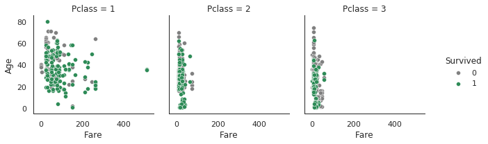

```python
g = sns.FacetGrid(df_train, hue='Survived', col='Pclass', margin_titles=True,
                  palette={1:"seagreen", 0:'gray'})
g=g.map(plt.scatter, "Fare", 'Age', edgecolor='w').add_legend();
```

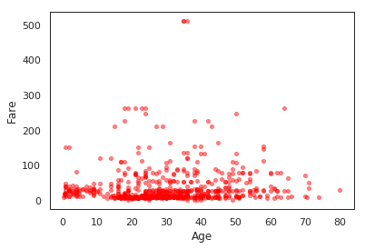

```python
df_train.plot(kind = 'scatter', x='Age', y='Fare', alpha=.5, color='red')
```

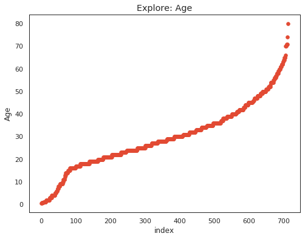

```python
#show scatter with mpl
plt.figure(figsize=(8,6))
plt.scatter(range(df_train.shape[0]), np.sort(df_train['Age'].values))
plt.xlabel("index")
plt.ylabel("Age")
plt.title('Explore: Age')
plt.show()
```

## Box Plot

depict groups of numberical data through quartiles.

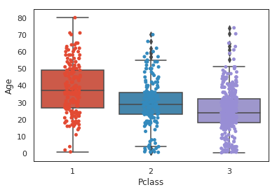

```python
ax= sns.boxplot(x="Pclass", y="Age", data=df_train)
ax= sns.stripplot(x='Pclass', y='Age', data=df_train, jitter=True, edgecolor='gray')
plt.show()
```

# Histogram

Gives an idea of what the distribution is

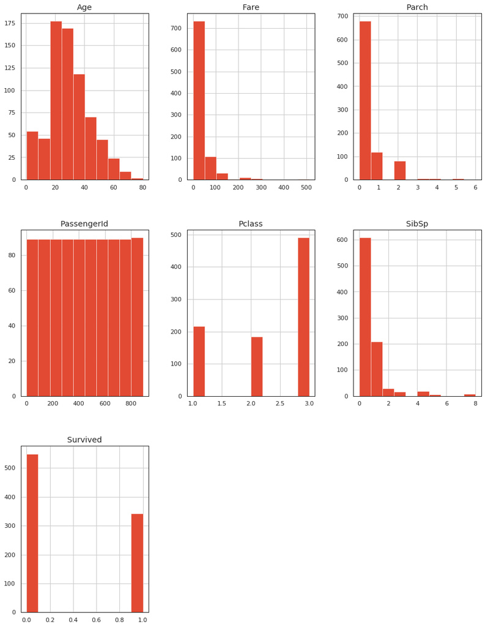

```python
df_train.hist(figsize=(15, 20))
plt.figure();
```

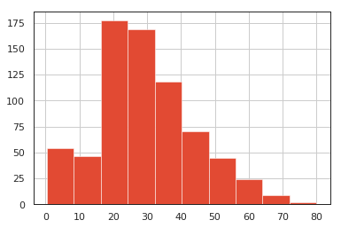

```python
df_train['Age'].hist()
```

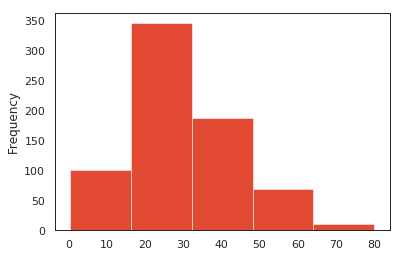

```python
df_train.Age.plot(kind='hist', bins=5)
```

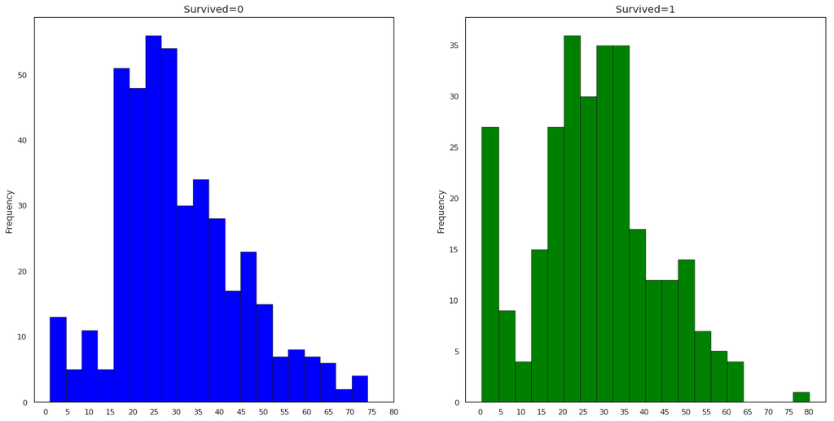

```python
f, ax=plt.subplots(1,2, figsize=(20,10))
df_train[df_train['Survived']==0].Age.plot.hist(ax=ax[0],bins=20, edgecolor='black', color='252525')
ax[0].set_title('Survived=0')
x1=list(range(0,85,5))
ax[0].set_xticks(x1)
df_train[df_train['Survived'] ==1].Age.plot.hist(ax=ax[1], color='green', bins=20, edgecolor='black')
ax[1].set_title('Survived=1')
x2=list(range(0,85,5))
ax[1].set_xticks(x2)
plt.show()
```

```python
f, ax=plt.subplots(1,2,figsize=(18,8))
df_train['Survived'].value_counts().plot.pie(explode=[0,0.1],autopct='%1.1f%%', ax=ax[0],shadow=True)
ax[0].set_title('Survived')
ax[0].set_ylabel('')
sns.countplot('Survived', data=df_train, ax=ax[1])
ax[1].set_title('Survived')
plt.show()
```

[figure not shown]

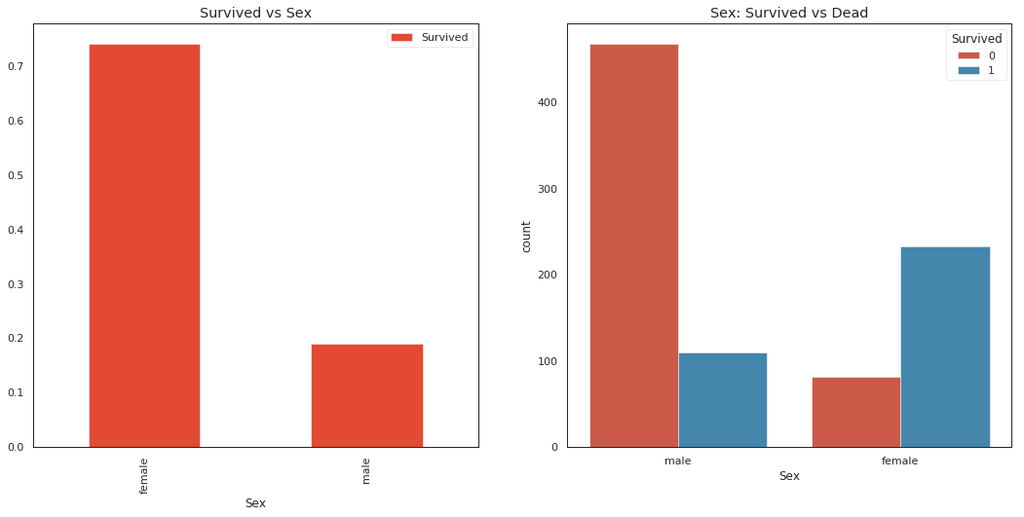

```python
f, ax=plt.subplots(1,2, figsize=(18, 8))
df_train[['Sex', 'Survived']].groupby(['Sex']).mean().plot.bar(ax=ax[0])
ax[0].set_title('Survived vs Sex')
sns.countplot('Sex', hue='Survived', data=df_train,ax=ax[1])
ax[1].set_title('Sex: Survived vs Dead')
plt.show()
```

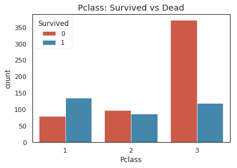

```python
sns.countplot('Pclass', hue='Survived', data=df_train)
plt.title('Pclass: Survived vs Dead')
plt.show()
```

# Multivariate Plots

Look at interactions between the variables

Good for spotting structured relationshios between inpiut variables

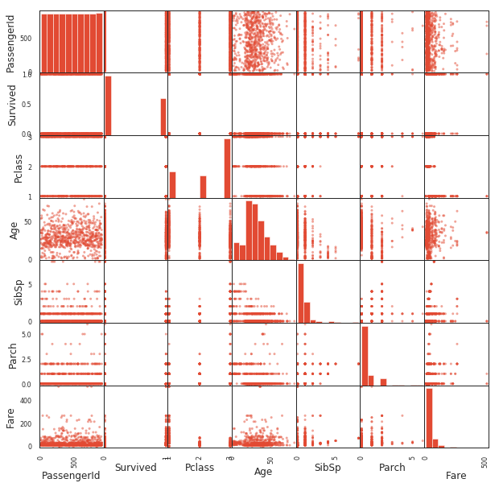

```python
#scatter plot matrix
pd.plotting.scatter_matrix(df_train, figsize=(10,10))
plt.figure()
```

# Violinplots

Shows distribution of quantitative data across several levels of one (or more) categorical variables such that those distributions can be compared. Unlike a box plot, in which all of the plot components correspond to actual datapoints, the violin plot features a kernel density estimation of the underlying distribution.

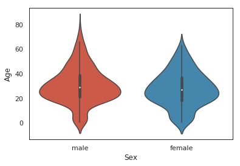

```python
sns.violinplot(data=df_train, x='Sex', y='Age')
```

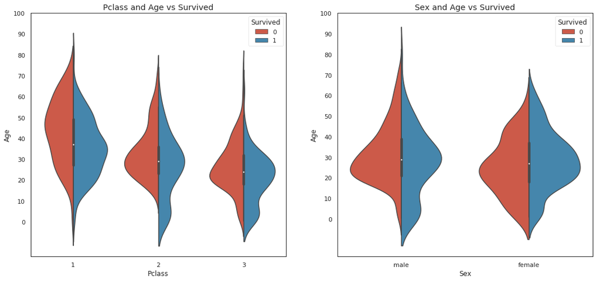

```python
f, ax = plt.subplots(1, 2, figsize=(18, 8))
sns.violinplot("Pclass", "Age", hue='Survived', data=df_train, split=True, ax=ax[0])
ax[0].set_title('Pclass and Age vs Survived')
ax[0].set_yticks(range(0, 110, 10))
sns.violinplot("Sex", "Age", hue='Survived', data=df_train, split=True, ax=ax[1])
ax[1].set_title('Sex and Age vs Survived')
ax[1].set_yticks(range(0,110, 10))
plt.show()
```

# Pairplot

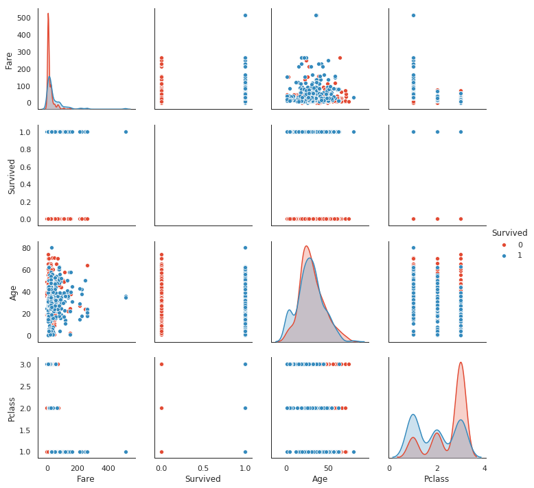

```python
# use seaborn pairplot to see the bivariate relationship between each pair of features

sns.pairplot(data=df_train[["Fare", "Survived", "Age", "Pclass"]],
            hue= "Survived", dropna=True)
```

# KDEplot

replace histograms shows in the diagonal of the pairplot by kde

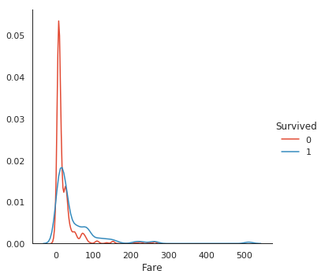

```python
sns.FacetGrid(df_train, hue='Survived', size=5).map(sns.kdeplot, "Fare").add_legend()
plt.show()
```

# Jointplot

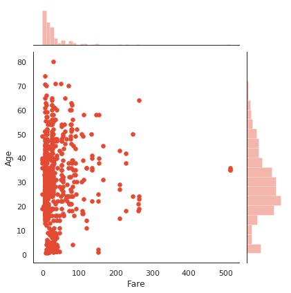

```python
sns.jointplot(x='Fare', y='Age', data=df_train)
```

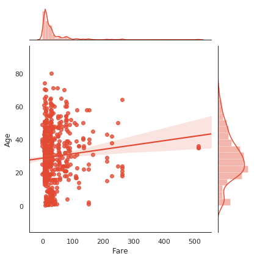

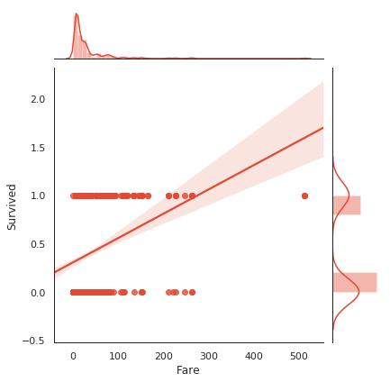

```python
sns.jointplot(x='Fare', y='Age', data=df_train, kind='reg')
sns.jointplot(x='Fare', y='Survived', data=df_train, kind='reg')
```

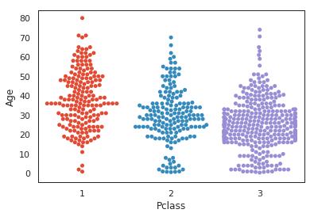

```python
sns.swarmplot(x='Pclass', y='Age', data=df_train)
```

# Heatmap

A heatmap is a two-dimensional graphgical representation of data where the indiviudla values that are contained in a matrix are represented as colors

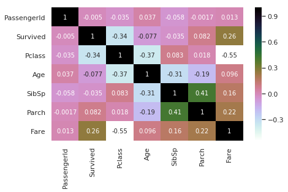

```python
plt.figure(figsize=(7, 4))
sns.heatmap(df_train.corr(), annot=True, cmap='cubehelix_r')#draws heatmap with inout as to the correlation matrix caluclcated by (iris.corr())
plt.show()
```

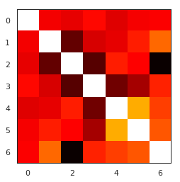

```python
plt.imshow(df_train.corr(), cmap='hot', interpolation='nearest')
plt.show()
```

# Bar Plot

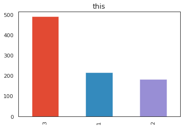

```python
df_train['Pclass'].value_counts().plot(kind="bar")
plt.title("this")
```

# Factorplot

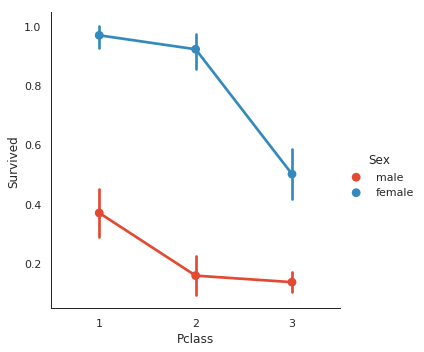

```python
sns.factorplot('Pclass','Survived',hue='Sex',data=df_train)
plt.show();
```

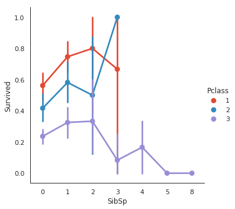

```python
sns.factorplot('SibSp','Survived',hue='Pclass',data=df_train)
plt.show()
```

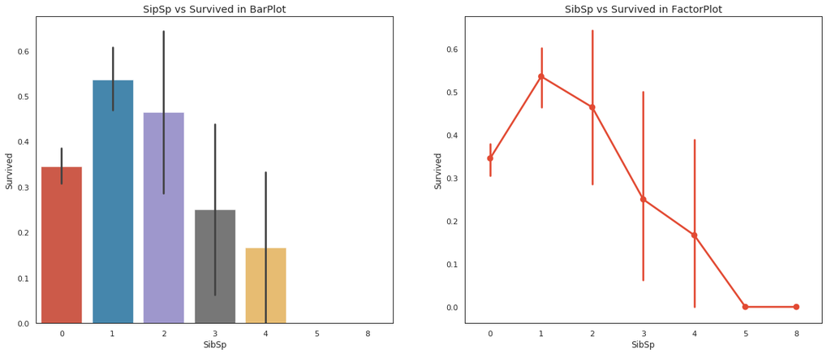

```python
#let's see some others factorplot
f,ax=plt.subplots(1,2,figsize=(20,8))
sns.barplot('SibSp','Survived', data=df_train,ax=ax[0])
ax[0].set_title('SipSp vs Survived in BarPlot')
sns.factorplot('SibSp','Survived', data=df_train,ax=ax[1])
ax[1].set_title('SibSp vs Survived in FactorPlot')
plt.close(2)
plt.show();
```

# Distplot

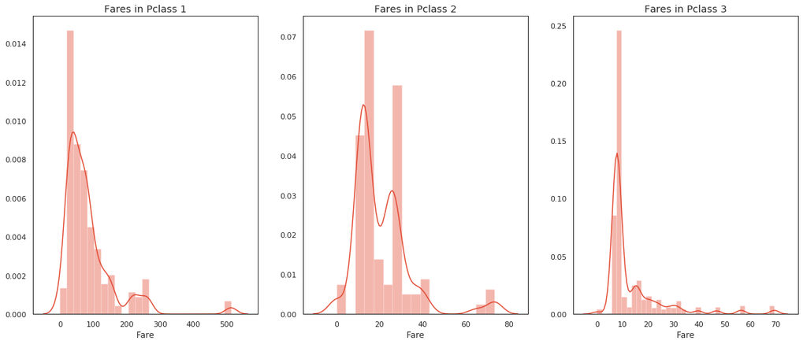

```python
f,ax=plt.subplots(1,3,figsize=(20,8))
sns.distplot(df_train[df_train['Pclass']==1].Fare,ax=ax[0])
ax[0].set_title('Fares in Pclass 1')
sns.distplot(df_train[df_train['Pclass']==2].Fare,ax=ax[1])
ax[1].set_title('Fares in Pclass 2')
sns.distplot(df_train[df_train['Pclass']==3].Fare,ax=ax[2])
ax[2].set_title('Fares in Pclass 3')
plt.show()
```

# Preprocessing

```python
def check_missing_data(df):
    flag=df.isna().sum().any()
    if flag==True:
        total = df.isnull().sum()
        percent = (df.isnull().sum())/(df.isnull().count()*100)
        output = pd.concat([total, percent], axis=1, keys=['Total', 'Percent'])
        data_type = []
        # written by MJ Bahmani
        for col in df.columns:
            dtype = str(df[col].dtype)
            data_type.append(dtype)
        output['Types'] = data_type
        return(np.transpose(output))
    else:
        return(False)
```

```python
check_missing_data(df_train)
```

|  | PassengerId | Survived | Pclass | Name | Sex | Age | SibSp | Parch | Ticket | Fare | Cabin | Embarked |
| --- | --- | --- | --- | --- | --- | --- | --- | --- | --- | --- | --- | --- |
| Total | 0 | 0 | 0 | 0 | 0 | 177 | 0 | 0 | 0 | 0 | 687 | 2 |
| Percent | 0 | 0 | 0 | 0 | 0 | 0.00198653 | 0 | 0 | 0 | 0 | 0.00771044 | 2.24467e-05 |
| Types | int64 | int64 | int64 | object | object | float64 | int64 | int64 | object | float64 | object | object |

```python
check_missing_data(df_test)
```

|  | PassengerId | Pclass | Name | Sex | Age | SibSp | Parch | Ticket | Fare | Cabin | Embarked |
| --- | --- | --- | --- | --- | --- | --- | --- | --- | --- | --- | --- |
| Total | 0 | 0 | 0 | 0 | 86 | 0 | 0 | 0 | 1 | 327 | 0 |
| Percent | 0 | 0 | 0 | 0 | 0.00205742 | 0 | 0 | 0 | 2.39234e-05 | 0.00782297 | 0 |
| Types | int64 | int64 | object | object | float64 | int64 | int64 | object | float64 | object | object |

```python
print(df_train.shape)
```

```
(891, 12)
```

```python
df_train.info()
```

```
<class 'pandas.core.frame.DataFrame'>
RangeIndex: 891 entries, 0 to 890
Data columns (total 12 columns):
PassengerId    891 non-null int64
Survived       891 non-null int64
Pclass         891 non-null int64
Name           891 non-null object
Sex            891 non-null object
Age            714 non-null float64
SibSp          891 non-null int64
Parch          891 non-null int64
Ticket         891 non-null object
Fare           891 non-null float64
Cabin          204 non-null object
Embarked       889 non-null object
dtypes: float64(2), int64(5), object(5)
memory usage: 83.6+ KB
```

```python
df_train['Embarked'].unique()
```

```
array(['S', 'C', 'Q', nan], dtype=object)
```

```python
df_train.groupby('Survived').count()
```

| Survived | PassengerId | Pclass | Name | Sex | Age | SibSp | Parch | Ticket | Fare | Cabin | Embarked |
| --- | --- | --- | --- | --- | --- | --- | --- | --- | --- | --- | --- |
| 0 | 549 | 549 | 549 | 549 | 424 | 549 | 549 | 549 | 549 | 68 | 549 |
| 1 | 342 | 342 | 342 | 342 | 290 | 342 | 342 | 342 | 342 | 136 | 340 |

```python
df_train.columns
```

```
Index(['PassengerId', 'Survived', 'Pclass', 'Name', 'Sex', 'Age', 'SibSp',
       'Parch', 'Ticket', 'Fare', 'Cabin', 'Embarked'],
      dtype='object')
```

```python
df_train[df_train['Age']==30]
```

|  | PassengerId | Survived | Pclass | Name | Sex | Age | SibSp | Parch | Ticket | Fare | Cabin | Embarked |
| --- | --- | --- | --- | --- | --- | --- | --- | --- | --- | --- | --- | --- |
| 79 | 80 | 1 | 3 | Dowdell, Miss. Elizabeth | female | 30.0 | 0 | 0 | 364516 | 12.4750 | NaN | S |
| 157 | 158 | 0 | 3 | Corn, Mr. Harry | male | 30.0 | 0 | 0 | SOTON/OQ 392090 | 8.0500 | NaN | S |
| 178 | 179 | 0 | 2 | Hale, Mr. Reginald | male | 30.0 | 0 | 0 | 250653 | 13.0000 | NaN | S |
| 213 | 214 | 0 | 2 | Givard, Mr. Hans Kristensen | male | 30.0 | 0 | 0 | 250646 | 13.0000 | NaN | S |
| 219 | 220 | 0 | 2 | Harris, Mr. Walter | male | 30.0 | 0 | 0 | W/C 14208 | 10.5000 | NaN | S |
| 244 | 245 | 0 | 3 | Attalah, Mr. Sleiman | male | 30.0 | 0 | 0 | 2694 | 7.2250 | NaN | C |
| 253 | 254 | 0 | 3 | Lobb, Mr. William Arthur | male | 30.0 | 1 | 0 | A/5. 3336 | 16.1000 | NaN | S |
| 257 | 258 | 1 | 1 | Cherry, Miss. Gladys | female | 30.0 | 0 | 0 | 110152 | 86.5000 | B77 | S |
| 286 | 287 | 1 | 3 | de Mulder, Mr. Theodore | male | 30.0 | 0 | 0 | 345774 | 9.5000 | NaN | S |
| 308 | 309 | 0 | 2 | Abelson, Mr. Samuel | male | 30.0 | 1 | 0 | P/PP 3381 | 24.0000 | NaN | C |
| 309 | 310 | 1 | 1 | Francatelli, Miss. Laura Mabel | female | 30.0 | 0 | 0 | PC 17485 | 56.9292 | E36 | C |
| 322 | 323 | 1 | 2 | Slayter, Miss. Hilda Mary | female | 30.0 | 0 | 0 | 234818 | 12.3500 | NaN | Q |
| 365 | 366 | 0 | 3 | Adahl, Mr. Mauritz Nils Martin | male | 30.0 | 0 | 0 | C 7076 | 7.2500 | NaN | S |
| 418 | 419 | 0 | 2 | Matthews, Mr. William John | male | 30.0 | 0 | 0 | 28228 | 13.0000 | NaN | S |
| 452 | 453 | 0 | 1 | Foreman, Mr. Benjamin Laventall | male | 30.0 | 0 | 0 | 113051 | 27.7500 | C111 | C |
| 488 | 489 | 0 | 3 | Somerton, Mr. Francis William | male | 30.0 | 0 | 0 | A.5. 18509 | 8.0500 | NaN | S |
| 520 | 521 | 1 | 1 | Perreault, Miss. Anne | female | 30.0 | 0 | 0 | 12749 | 93.5000 | B73 | S |
| 534 | 535 | 0 | 3 | Cacic, Miss. Marija | female | 30.0 | 0 | 0 | 315084 | 8.6625 | NaN | S |
| 537 | 538 | 1 | 1 | LeRoy, Miss. Bertha | female | 30.0 | 0 | 0 | PC 17761 | 106.4250 | NaN | C |
| 606 | 607 | 0 | 3 | Karaic, Mr. Milan | male | 30.0 | 0 | 0 | 349246 | 7.8958 | NaN | S |
| 726 | 727 | 1 | 2 | Renouf, Mrs. Peter Henry (Lillian Jefferys) | female | 30.0 | 3 | 0 | 31027 | 21.0000 | NaN | S |
| 747 | 748 | 1 | 2 | Sinkkonen, Miss. Anna | female | 30.0 | 0 | 0 | 250648 | 13.0000 | NaN | S |
| 798 | 799 | 0 | 3 | Ibrahim Shawah, Mr. Yousseff | male | 30.0 | 0 | 0 | 2685 | 7.2292 | NaN | C |
| 799 | 800 | 0 | 3 | Van Impe, Mrs. Jean Baptiste (Rosalie Paula Go... | female | 30.0 | 1 | 1 | 345773 | 24.1500 | NaN | S |
| 842 | 843 | 1 | 1 | Serepeca, Miss. Augusta | female | 30.0 | 0 | 0 | 113798 | 31.0000 | NaN | C |

```python
X = df_train.iloc[:, :-1].values
y = df_train.iloc[:, -1].values
```

```python
train = df_train.dropna()
```

## Cleaning :

1. Tranforming

```python
def simplify_ages(df):
    df.Age = df.Age.fillna(-0.5)
    bins = (-1, 0, 5, 12, 18, 25, 35, 60, 120)
    group_names = ['Unknown', 'Baby', 'Child', 'Teenager', 'Student', 'Young Adult', 'Adult', 'Senior']
    categories = pd.cut(df.Age, bins, labels=group_names)
    df.Age = categories
    return df

def simplify_cabins(df):
    df.Cabin = df.Cabin.fillna('N')
    df.Cabin = df.Cabin.apply(lambda x: x[0])
    return df

def simplify_fares(df):
    df.Fare = df.Fare.fillna(-0.5)
    bins = (-1, 0, 8, 15, 31, 1000)
    group_names = ['Unknown', '1_quartile', '2_quartile', '3_quartile', '4_quartile']
    categories = pd.cut(df.Fare, bins, labels=group_names)
    df.Fare = categories
    return df

def format_name(df):
    df['Lname'] = df.Name.apply(lambda x: x.split(' ')[0])
    df['NamePrefix'] = df.Name.apply(lambda x: x.split(' ')[1])
    return df

def drop_features(df):
    return df.drop(['Ticket', 'Name', 'Embarked'], axis=1)

def transform_features(df):
    df = simplify_ages(df)
    df = simplify_cabins(df)
    df = simplify_fares(df)
    df = format_name(df)
    df = drop_features(df)
    return df

df_train = transform_features(df_train)
df_test = transform_features(df_test)
df_train.head()
```

|  | PassengerId | Survived | Pclass | Sex | Age | SibSp | Parch | Fare | Cabin | Lname | NamePrefix |
| --- | --- | --- | --- | --- | --- | --- | --- | --- | --- | --- | --- |
| 0 | 1 | 0 | 3 | male | Student | 1 | 0 | 1_quartile | N | Braund, | Mr. |
| 1 | 2 | 1 | 1 | female | Adult | 1 | 0 | 4_quartile | C | Cumings, | Mrs. |
| 2 | 3 | 1 | 3 | female | Young Adult | 0 | 0 | 1_quartile | N | Heikkinen, | Miss. |
| 3 | 4 | 1 | 1 | female | Young Adult | 1 | 0 | 4_quartile | C | Futrelle, | Mrs. |
| 4 | 5 | 0 | 3 | male | Young Adult | 0 | 0 | 2_quartile | N | Allen, | Mr. |

# Feature Encoding

Must ALWAYS change categorical variables to numerical values.

```python
def encode_features(df_train, df_test):
    features = ['Fare', 'Cabin', 'Age', 'Sex', 'Lname', 'NamePrefix']
    df_combined = pd.concat([df_train[features], df_test[features]])

    for feature in features:
        le = preprocessing.LabelEncoder()
        le = le.fit(df_combined[feature])
        df_train[feature] = le.transform(df_train[feature])
        df_test[feature] = le.transform(df_test[feature])
    return df_train, df_test
```

# Encode Dataset

```python
df_train, df_test = encode_features(df_train, df_test)
df_train.head()
```

|  | PassengerId | Survived | Pclass | Sex | Age | SibSp | Parch | Fare | Cabin | Lname | NamePrefix |
| --- | --- | --- | --- | --- | --- | --- | --- | --- | --- | --- | --- |
| 0 | 1 | 0 | 3 | 1 | 4 | 1 | 0 | 0 | 7 | 100 | 19 |
| 1 | 2 | 1 | 1 | 0 | 0 | 1 | 0 | 3 | 2 | 182 | 20 |
| 2 | 3 | 1 | 3 | 0 | 7 | 0 | 0 | 0 | 7 | 329 | 16 |
| 3 | 4 | 1 | 1 | 0 | 7 | 1 | 0 | 3 | 2 | 267 | 20 |
| 4 | 5 | 0 | 3 | 1 | 7 | 0 | 0 | 1 | 7 | 15 | 19 |

```python
x_all = df_train.drop(['Survived', 'PassengerId'], axis=1)
y_all = df_train['Survived']
```

```python
num_test = .3
X_train, X_test, y_train, y_test = train_test_split(x_all, y_all, test_size=num_test, random_state=100)
```

# Accuracy and precision

```
We know that the titanic problem is a binary classification and to evaluate, we just need to calculate the accuracy.
```

### accuracy

```
Your score is the percentage of passengers you correctly predict. This is known simply as "accuracy”.
```

### precision :

```
In pattern recognition, information retrieval and binary classification, precision (also called positive predictive value) is the fraction of relevant instances among the retrieved instances,
```

### recall :

```
recall is the fraction of relevant instances that have been retrieved over the total amount of relevant instances.
```

### F-score :

```
 the F1 score is a measure of a test's accuracy. It considers both the precision p and the recall r of the test to compute the score: p is the number of correct positive results divided by the number of all positive results returned by the classifier, and r is the number of correct positive results divided by the number of all relevant samples (all samples that should have been identified as positive). The F1 score is the harmonic average of the precision and recall, where an F1 score reaches its best value at 1 (perfect precision and recall) and worst at 0.
```

### What is the difference between accuracy and precision?

```
"Accuracy" and "precision" are general terms throughout science. A good way to internalize the difference are the common "bullseye diagrams". In machine learning/statistics as a whole, accuracy vs. precision is analogous to bias vs. variance.
```

# RandomForestClassifier

```python
rfc = RandomForestClassifier()

# Choose some parameter combinations to try
parameters = {'n_estimators': [4, 6, 9],
              'max_features': ['log2', 'sqrt','auto'],
              'criterion': ['entropy', 'gini'],
              'max_depth': [2, 3, 5, 10],
              'min_samples_split': [2, 3, 5],
              'min_samples_leaf': [1,5,8]
             }

# Type of scoring used to compare parameter combinations
acc_scorer = make_scorer(accuracy_score)

# Run the grid search
grid_obj = GridSearchCV(rfc, parameters, scoring=acc_scorer)
grid_obj = grid_obj.fit(X_train, y_train)

# Set the clf to the best combination of parameters
rfc = grid_obj.best_estimator_

# Fit the best algorithm to the data.
rfc.fit(X_train, y_train)
```

```
RandomForestClassifier(bootstrap=True, class_weight=None, criterion='gini',
                       max_depth=10, max_features='sqrt', max_leaf_nodes=None,
                       min_impurity_decrease=0.0, min_impurity_split=None,
                       min_samples_leaf=8, min_samples_split=5,
                       min_weight_fraction_leaf=0.0, n_estimators=4,
                       n_jobs=None, oob_score=False, random_state=None,
                       verbose=0, warm_start=False)
```

```python
rfc_prediction = rfc.predict(X_test)
rfc_score=accuracy_score(y_test, rfc_prediction)
print(rfc_score)
```

```
0.7947761194029851
```

# Gradient Boosting

```python
xgboost = xgb.XGBClassifier(max_depth=3, n_estimators=300, learning_rate=0.05).fit(X_train, y_train)
```

# Prediction

```python
xgb_prediction = xgboost.predict(X_test)
xgb_score=accuracy_score(y_test, xgb_prediction)
print(xgb_score)
```

```
0.8134328358208955
```

# Logreg

```python
logreg = LogisticRegression()
logreg.fit(X_train, y_train)
```

```
LogisticRegression(C=1.0, class_weight=None, dual=False, fit_intercept=True,
                   intercept_scaling=1, l1_ratio=None, max_iter=100,
                   multi_class='warn', n_jobs=None, penalty='l2',
                   random_state=None, solver='warn', tol=0.0001, verbose=0,
                   warm_start=False)
```

```python
logreg_prediction = logreg.predict(X_test)
logreg_score=accuracy_score(y_test, logreg_prediction)
print(logreg_score)
```

```
0.7947761194029851
```

# Decision Tree Regressor

Mean Squared Error is to meature quality of the split.

```python
from sklearn.tree import DecisionTreeRegressor

# define model. specify a number for random_state to ensure same results e/ run
dt = DecisionTreeRegressor(random_state=1)
```

```python
#fit model

dt.fit(X_train, y_train)
```

```
DecisionTreeRegressor(criterion='mse', max_depth=None, max_features=None,
                      max_leaf_nodes=None, min_impurity_decrease=0.0,
                      min_impurity_split=None, min_samples_leaf=1,
                      min_samples_split=2, min_weight_fraction_leaf=0.0,
                      presort=False, random_state=1, splitter='best')
```

```python
dt_prediction = dt.predict(X_test)
dt_score = accuracy_score(y_test, dt_prediction)
print(dt_score)
```

```
0.7835820895522388
```

# Extra Tree Regressor

differ: WHen looking for the best split to sepearate the sames opf a node into two groups, random splits are drawn from each of the max_features randomly selected features and the best splot among those chosen. When max_features is set to 1, it is a totally random decision tree

```python
from sklearn.tree import ExtraTreeRegressor
#define model. SPecify a number for random_state to ensure same results e/ run.

etr = ExtraTreeRegressor()
```

```python
# fit model
etr.fit(X_train, y_train)
```

```
ExtraTreeRegressor(criterion='mse', max_depth=None, max_features='auto',
                   max_leaf_nodes=None, min_impurity_decrease=0.0,
                   min_impurity_split=None, min_samples_leaf=1,
                   min_samples_split=2, min_weight_fraction_leaf=0.0,
                   random_state=None, splitter='random')
```

```python
etr_prediction = etr.predict(X_test)
etr_score = accuracy_score(y_test, etr_prediction)
print(etr_score)
```

```
0.7723880597014925
```

```python
X_train = df_train.drop("Survived", axis=1)
y_train = df_train['Survived']
```

```python
X_train = X_train.drop("PassengerId", axis=1)
X_test = df_test.drop("PassengerId", axis=1)
```

```python
xgboost = xgb.XGBClassifier(max_depth=3, n_estimators=300, learning_rate=0.05).fit(X_train, y_train)
```

```python
y_pred = xgboost.predict(X_test)
```

```python
submission = pd.DataFrame({
        "PassengerId": df_test["PassengerId"],
        "Survived": y_pred
    })
submission.to_csv('submission.csv', index=False)
```